# Detecting SMS Spam Using Machine Learning

By : Bayu Raka Janasri

6/14/2021

# 1 Introduction

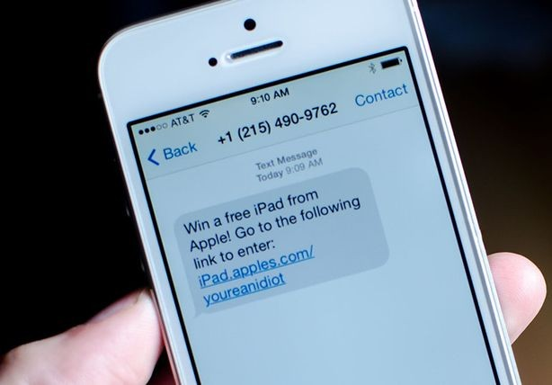

Always get spam sms from anonim number?

We get same problem here!!

So this time we will build machine learning model for detecting spam messages.

Source dataset : https://www.kaggle.com/shravan3273/sms-spam

# 2 Import Library

```r
library(dplyr)
library(e1071)
library(tm)
library(caret)
library(wordcloud)
library(RColorBrewer)
```

# 3 Read Data

```r
sms <- read.csv("spamraw.csv")
```

# 4 Data Wrangling

**Check data type**

```r
glimpse(sms)
```

```
## Rows: 5,559
## Columns: 2
## $ type <chr> "ham", "ham", "ham", "spam", "spam", "ham", "ham", "ham", "spam",…
## $ text <chr> "Hope you are having a good week. Just checking in", "K..give bac…
```

**Check first 5 rows of our dataset**

```r
head(sms,5)
```

|  | type | text |
| --- | --- | --- |
| 1 | ham | Hope you are having a good week. Just checking in |
| 2 | ham | K..give back my thanks. |
| 3 | ham | Am also doing in cbe only. But have to pay. |
| 4 | spam | complimentary 4 STAR Ibiza Holiday or £10,000 cash needs your URGENT collection. 09066364349 NOW from Landline not to lose out! Box434SK38WP150PPM18+ |
| 5 | spam | okmail: Dear Dave this is your final notice to collect your 4* Tenerife Holiday or #5000 CASH award! Call 09061743806 from landline. TCs SAE Box326 CW25WX 150ppm |

**Change data type**

We have to change data type into factor.

```r
sms <- sms %>%
    mutate(type = as.factor(type))

head(sms)
```

|  | type | text |
| --- | --- | --- |
| 1 | ham | Hope you are having a good week. Just checking in |
| 2 | ham | K..give back my thanks. |
| 3 | ham | Am also doing in cbe only. But have to pay. |
| 4 | spam | complimentary 4 STAR Ibiza Holiday or £10,000 cash needs your URGENT collection. 09066364349 NOW from Landline not to lose out! Box434SK38WP150PPM18+ |
| 5 | spam | okmail: Dear Dave this is your final notice to collect your 4* Tenerife Holiday or #5000 CASH award! Call 09061743806 from landline. TCs SAE Box326 CW25WX 150ppm |
| 6 | ham | Aiya we discuss later lar... Pick u up at 4 is it? |

**Check Missing Values**

```r
colSums(is.na(sms))
```

```
## type text
##    0    0
```

There is no missing value at our dataset.

# 5 Exploratory Data Analysis (EDA)

**Check propotion our dataset**

```r
prop.table(table(sms$type))
```

```
##
##       ham      spam
## 0.8656233 0.1343767
```

**See first 5 sms**

```r
head(sms$text,5)
```

```
## [1] "Hope you are having a good week. Just checking in"
## [2] "K..give back my thanks."
## [3] "Am also doing in cbe only. But have to pay."
## [4] "complimentary 4 STAR Ibiza Holiday or £10,000 cash needs your URGENT collection. 09066364349 NOW from Landline not to lose out! Box434SK38WP150PPM18+"
## [5] "okmail: Dear Dave this is your final notice to collect your 4* Tenerife Holiday or #5000 CASH award! Call 09061743806 from landline. TCs SAE Box326 CW25WX 150ppm"
```

## 5.1 Data Pre-processing

### 5.1.1 Text to Corpus

We use package `tm` to text mining. We will change data to text with function `VCorpus()`.

**Change Text to Corpus**

```r
sms.corpus <- VCorpus(VectorSource(sms$text))
```

### 5.1.2 Text Cleansing

We have to remove some numbers, changing to lowercase, remove some punctuation mark, etc.

```r
sms.corpus <- sms.corpus %>%
              tm_map(removeNumbers) %>% # remove numerical character
              tm_map(content_transformer(tolower)) %>% #lowercase
              tm_map(removeWords, stopwords("english")) %>% # remove english stopwords (and, the, am)
              tm_map(removePunctuation) %>%  # remove punctuation mark
              tm_map(stemDocument) %>% # stem word (e.g. from walking to walk)
              tm_map(stripWhitespace) # strip double white space
```

**Check text content**

Get content at row 111.

```r
sms.corpus[[111]]$content
```

```
## [1] "wow healthi old airport rd lor cant thk anyth els b bath dog later"
```

### 5.1.3 Document-Term Matrix (DTM)

After cleansing our text we have to change text into `DTM`, the process is called **Tokenization**. Splitting one sentence into others `term`.

```r
sms.dtm <- DocumentTermMatrix(sms.corpus)
as.data.frame(head(as.matrix(sms.dtm)))
```

|  | ‘morrow | ‘rent | ’llspeak | ’re | ’scool | ’ve | “harri | ”leafcutt | £award | £call | £ea | £million | £minmobsmorelkpoboxhpfl | £month | £morefrmmob | £msg | £perweeksub | £perwksub | £pm | £pmmorefrommobilebremovedmobypoboxlsyf | £week | £wk | €˜ll | €˜m | €˜re | €˜s | €˜ve | €œharri | €™m | … |
| --- | --- | --- | --- | --- | --- | --- | --- | --- | --- | --- | --- | --- | --- | --- | --- | --- | --- | --- | --- | --- | --- | --- | --- | --- | --- | --- | --- | --- | --- | --- |
| 1 | 0 | 0 | 0 | 0 | 0 | 0 | 0 | 0 | 0 | 0 | 0 | 0 | 0 | 0 | 0 | 0 | 0 | 0 | 0 | 0 | 0 | 0 | 0 | 0 | 0 | 0 | 0 | 0 | 0 | … |
| 2 | 0 | 0 | 0 | 0 | 0 | 0 | 0 | 0 | 0 | 0 | 0 | 0 | 0 | 0 | 0 | 0 | 0 | 0 | 0 | 0 | 0 | 0 | 0 | 0 | 0 | 0 | 0 | 0 | 0 | … |
| 3 | 0 | 0 | 0 | 0 | 0 | 0 | 0 | 0 | 0 | 0 | 0 | 0 | 0 | 0 | 0 | 0 | 0 | 0 | 0 | 0 | 0 | 0 | 0 | 0 | 0 | 0 | 0 | 0 | 0 | … |
| 4 | 0 | 0 | 0 | 0 | 0 | 0 | 0 | 0 | 0 | 0 | 0 | 0 | 0 | 0 | 0 | 0 | 0 | 0 | 0 | 0 | 0 | 0 | 0 | 0 | 0 | 0 | 0 | 0 | 0 | … |
| 5 | 0 | 0 | 0 | 0 | 0 | 0 | 0 | 0 | 0 | 0 | 0 | 0 | 0 | 0 | 0 | 0 | 0 | 0 | 0 | 0 | 0 | 0 | 0 | 0 | 0 | 0 | 0 | 0 | 0 | … |
| 6 | 0 | 0 | 0 | 0 | 0 | 0 | 0 | 0 | 0 | 0 | 0 | 0 | 0 | 0 | 0 | 0 | 0 | 0 | 0 | 0 | 0 | 0 | 0 | 0 | 0 | 0 | 0 | 0 | 0 | … |

**Inspect DTM**

Check our dtm data.

```r
inspect(sms.dtm)
```

```
## <<DocumentTermMatrix (documents: 5559, terms: 6559)>>
## Non-/sparse entries: 42147/36419334
## Sparsity           : 100%
## Maximal term length: 40
## Weighting          : term frequency (tf)
## Sample             :
##       Terms
## Docs   call can come day free get just know now will
##   1814    1   0    0   0    0   0    0    0   0    0
##   2046    0   0    0   0    0   0    0    1   0    0
##   295     0   0    0   0    1   0    0    0   0    0
##   2993    0   1    0   1    0   0    0    0   0    0
##   313     0   0    1   2    0   1    0    0   0   11
##   3201    0   0    0   0    1   0    0    0   0    0
##   3522    0   0    0   0    0   0    0    0   0    0
##   399     0   0    0   0    0   0    0    0   0    0
##   5068    0   0    0   6    0   0    0    0   0    0
##   5279    0   3    0   0    1   1    0    0   0    0
```

```r
sms[1000,"text"]
```

```
## [1] "K..k...from tomorrow onwards started ah?"
```

## 5.2 Cross Validation

Before making model we have to split our data train into `data train` and `data test` with the composition 80% as data train.

```r
set.seed(123)

index <- sample(nrow(sms.dtm), nrow(sms.dtm)*0.80)

data_train <- sms.dtm[index, ]
data_test <- sms.dtm[-index,]
```

**Prepare data label target**

```r
label_train <- sms[index, "type"]
label_test <- sms[-index, "type"]
```

**Check propotion class target data train**

```r
prop.table(table(label_train))
```

```
## label_train
##       ham      spam
## 0.8641781 0.1358219
```

We can see our propotion here where is ham **86%** and spam **13%**.

## 5.3 Further Data Pre-processing

```r
sms_freq <- findFreqTerms(x = data_train, lowfreq = 20)
```

**Check** `sms_freq` **head**

```r
head(sms_freq, 20)
```

```
##  [1] "abl"       "abt"       "account"   "actual"    "afternoon" "aight"
##  [7] "alreadi"   "alright"   "also"      "alway"     "anoth"     "answer"
## [13] "anyth"     "anyway"    "appli"     "around"    "ask"       "await"
## [19] "award"     "away"
```

**Make dataset that words only appear at `sms_freq`**

```r
data_train <- data_train[, sms_freq]
```

**Make Bernauli Converter**

```r
# fungsi DIY
bernoulli_conv <- function(x){
  x <- as.factor(ifelse(x > 0, 1, 0))
  return(x)
}

# coba fungsi
bernoulli_conv(c(0,1,3,0,12,4,0.3))
```

```
## [1] 0 1 1 0 1 1 1
## Levels: 0 1
```

**Input Bernoulli Converter into `data_test` and `data_train`:**

```r
data_train_bn <- apply(X = data_train, MARGIN = 2, FUN = bernoulli_conv)
data_test_bn <- apply(X = data_test, MARGIN = 2, FUN = bernoulli_conv)
```

**See the result**

```r
data_train_bn[20:30, 50:60]
```

```
##       Terms
## Docs   check claim class code collect come contact cool cos cost credit
##   4444 "0"   "0"   "0"   "0"  "0"     "0"  "0"     "0"  "0" "0"  "0"
##   1017 "0"   "0"   "0"   "0"  "0"     "0"  "0"     "0"  "0" "0"  "0"
##   2013 "0"   "0"   "0"   "0"  "0"     "0"  "0"     "0"  "0" "0"  "0"
##   5475 "0"   "0"   "0"   "0"  "1"     "0"  "0"     "0"  "0" "0"  "0"
##   2888 "0"   "0"   "0"   "0"  "0"     "0"  "0"     "0"  "0" "0"  "0"
##   2567 "0"   "0"   "0"   "0"  "0"     "0"  "0"     "0"  "0" "0"  "0"
##   1450 "0"   "0"   "0"   "0"  "0"     "0"  "0"     "0"  "1" "0"  "0"
##   1790 "0"   "0"   "0"   "0"  "0"     "0"  "0"     "0"  "0" "0"  "0"
##   4307 "0"   "0"   "0"   "0"  "0"     "0"  "0"     "0"  "0" "0"  "0"
##   2980 "0"   "0"   "0"   "0"  "0"     "0"  "0"     "0"  "1" "0"  "0"
##   1614 "0"   "0"   "0"   "0"  "0"     "0"  "0"     "0"  "0" "0"  "0"
```

# 6 Model Fitting

We make `Naive Bayes` model based on our dataset that we already have processed.

```r
model_naive <- naiveBayes(x = data_train_bn,
                          y = label_train,
                          laplace = 1)
```

Change into dataframe if we want to see data from `data_train_bn`.

```r
as.data.frame(head(data_train_bn))
```

|  | abl | abt | account | actual | afternoon | aight | alreadi | alright | also | alway | anoth | answer | anyth | anyway | appli | around | ask | await | award | away | babe | babi | back | bad | bed | best | better | big | birthday | … |
| --- | --- | --- | --- | --- | --- | --- | --- | --- | --- | --- | --- | --- | --- | --- | --- | --- | --- | --- | --- | --- | --- | --- | --- | --- | --- | --- | --- | --- | --- | --- |
| 2463 | 0 | 0 | 0 | 0 | 0 | 0 | 0 | 0 | 0 | 0 | 0 | 0 | 0 | 0 | 0 | 0 | 0 | 0 | 0 | 0 | 0 | 0 | 0 | 0 | 0 | 0 | 0 | 0 | 0 | … |
| 2511 | 0 | 0 | 0 | 0 | 0 | 0 | 0 | 0 | 0 | 0 | 0 | 0 | 0 | 0 | 0 | 0 | 0 | 0 | 0 | 0 | 0 | 0 | 0 | 0 | 0 | 0 | 0 | 0 | 0 | … |
| 2227 | 0 | 0 | 0 | 0 | 0 | 0 | 0 | 0 | 0 | 0 | 0 | 0 | 0 | 0 | 0 | 0 | 0 | 0 | 0 | 0 | 0 | 0 | 0 | 0 | 0 | 0 | 0 | 0 | 0 | … |
| 526 | 0 | 0 | 0 | 0 | 0 | 0 | 0 | 0 | 0 | 0 | 0 | 0 | 0 | 0 | 0 | 0 | 0 | 0 | 0 | 0 | 0 | 0 | 0 | 0 | 0 | 0 | 0 | 0 | 0 | … |
| 4291 | 0 | 0 | 0 | 0 | 0 | 0 | 0 | 0 | 0 | 0 | 0 | 0 | 0 | 0 | 0 | 0 | 0 | 0 | 0 | 0 | 0 | 0 | 0 | 0 | 0 | 0 | 0 | 0 | 0 | … |
| 2986 | 0 | 0 | 0 | 0 | 0 | 0 | 0 | 0 | 0 | 0 | 0 | 0 | 0 | 0 | 0 | 0 | 0 | 0 | 0 | 0 | 0 | 0 | 0 | 0 | 0 | 0 | 0 | 0 | 0 | … |

## 6.1 Prediction

We try to predict our target at data test and save into `sms_predClass`.

```r
sms_predClass <- predict(object = model_naive,
                         newdata = data_test_bn,
                         type = "class")

head(sms_predClass)
```

```
## [1] spam ham  ham  ham  ham  ham
## Levels: ham spam
```

## 6.2 Model Evaluation

We use `confussion Matrix` to evaluate our `Naive Bayes` model.

```r
result <- confusionMatrix(data = sms_predClass, # hasil prediksi
                reference = label_test, # label aktual
                positive = "spam")
```

# 7 Conclusion

```r
result
```

```
## Confusion Matrix and Statistics
##
##           Reference
## Prediction ham spam
##       ham  961   22
##       spam   8  121
##
##                Accuracy : 0.973
##                  95% CI : (0.9617, 0.9817)
##     No Information Rate : 0.8714
##     P-Value [Acc > NIR] : < 2e-16
##
##                   Kappa : 0.8744
##
##  Mcnemar's Test P-Value : 0.01762
##
##             Sensitivity : 0.8462
##             Specificity : 0.9917
##          Pos Pred Value : 0.9380
##          Neg Pred Value : 0.9776
##              Prevalence : 0.1286
##          Detection Rate : 0.1088
##    Detection Prevalence : 0.1160
##       Balanced Accuracy : 0.9189
##
##        'Positive' Class : spam
##
```

Based on result above we got quite good model, our `accuracy` is **97%**, `sensitivity` is **84%**, `specificity` is **99%**, and `precision` is **93%**. We can get conclusion, our model is good to be detecting spam.

**Make wordcloud**

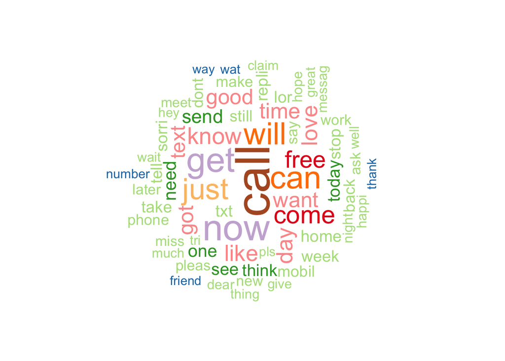

```r
wordcloud(words = sms.corpus, min.freq = 100, random.order = FALSE, rot.per=0.35, colors=brewer.pal(12, "Paired"))
```

From word cloud above, we can see words **call, now, get, can, will, come, free, just, etc** are mostly appear at the messages.